# Assignment_questions

Lily Slater

2022-11-14

### What states (of those I am willing to move to) have the highest paying data-related salaries? Differences between job sub-categoriES

#Loading datafile

```r
salary_data_states <- read.csv("~/Desktop/DS311/python_charmers/collab_files/salary_data_states.csv")
```

#Loading Packages

```r
library(dplyr)
```

```r
library(ggplot2)
library(knitr)
```

#Exploring the datafile

```r
names(salary_data_states)
```

```
##  [1] "CASE_NUMBER"                    "CASE_STATUS"
##  [3] "CASE_RECEIVED_DATE"             "DECISION_DATE"
##  [5] "EMPLOYER_NAME"                  "PREVAILING_WAGE_SUBMITTED"
##  [7] "PREVAILING_WAGE_SUBMITTED_UNIT" "PAID_WAGE_SUBMITTED"
##  [9] "PAID_WAGE_SUBMITTED_UNIT"       "JOB_TITLE"
## [11] "WORK_CITY"                      "EDUCATION_LEVEL_REQUIRED"
## [13] "COLLEGE_MAJOR_REQUIRED"         "EXPERIENCE_REQUIRED_Y_N"
## [15] "EXPERIENCE_REQUIRED_NUM_MONTHS" "COUNTRY_OF_CITIZENSHIP"
## [17] "PREVAILING_WAGE_SOC_CODE"       "PREVAILING_WAGE_SOC_TITLE"
## [19] "WORK_STATE"                     "WORK_STATE_ABBREVIATION"
## [21] "WORK_POSTAL_CODE"               "FULL_TIME_POSITION_Y_N"
## [23] "VISA_CLASS"                     "PREVAILING_WAGE_PER_YEAR"
## [25] "PAID_WAGE_PER_YEAR"             "JOB_TITLE_SUBGROUP"
## [27] "order"
```

```r
#sub-setting columns of interest
data_interest = data.frame(salary_data_states[c("WORK_STATE", "JOB_TITLE_SUBGROUP", "PAID_WAGE_PER_YEAR")])

#excluding rows with na's
data_int = na.exclude(data_interest)

#taking a look at jobs of interest [sub categories]
ff = data_int[data_int$JOB_TITLE_SUBGROUP == c("data analyst" ), ]
fg = data_int[data_int$JOB_TITLE_SUBGROUP == c( "data scientist"), ]

# group by work state
fm = distinct(ff, WORK_STATE, .keep_all = TRUE)
dfg = distinct(fg, WORK_STATE, .keep_all = TRUE)
#sorting
fm_sort <- fm[order(-fm$PAID_WAGE_PER_YEAR),]
da_df <- head(fm_sort)
dfg_sort <- dfg[order(-dfg$PAID_WAGE_PER_YEAR),]
da_dfg <- head(dfg_sort)

#Subsetting this data for states with high pay
da_dfcnn <- da_df[da_df$WORK_STATE %in% c("California", "New York", "New Jersey") ,]
dfg_dfcnn <- da_dfg[da_dfg$WORK_STATE %in% c("California", "New York", "New Jersey") ,]
```

Plotting this data to a scatterplot

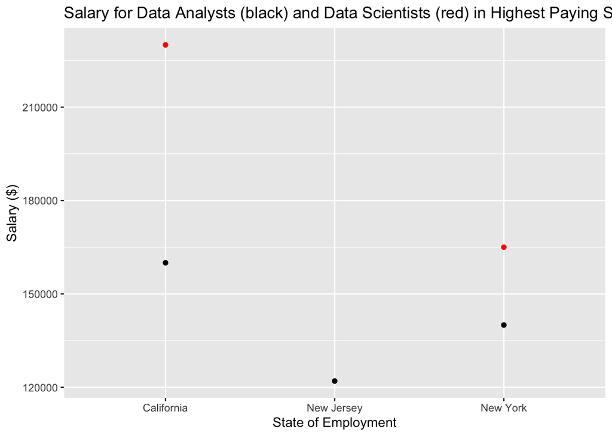

```r
ggplot() +
  geom_point(data = da_dfcnn, aes(WORK_STATE, PAID_WAGE_PER_YEAR), color = "black", size = 1.5) +
  geom_point(data = dfg_dfcnn , aes(WORK_STATE, PAID_WAGE_PER_YEAR), color = "red" , size = 1.5) +
  ggtitle("Salary for Data Analysts (black) and Data Scientists (red) in Highest Paying States")+
  xlab("State of Employment")+ ylab("Salary ($)")
```

Attempting to get data in one datafile to plot into bar graph

```r
fm = distinct(ff, WORK_STATE, .keep_all = TRUE)
dfg = distinct(fg, WORK_STATE, .keep_all = TRUE)
total_dfm <- merge(fm,dfg,by="WORK_STATE")
```

Sum data analyst and data scientist wage for each state

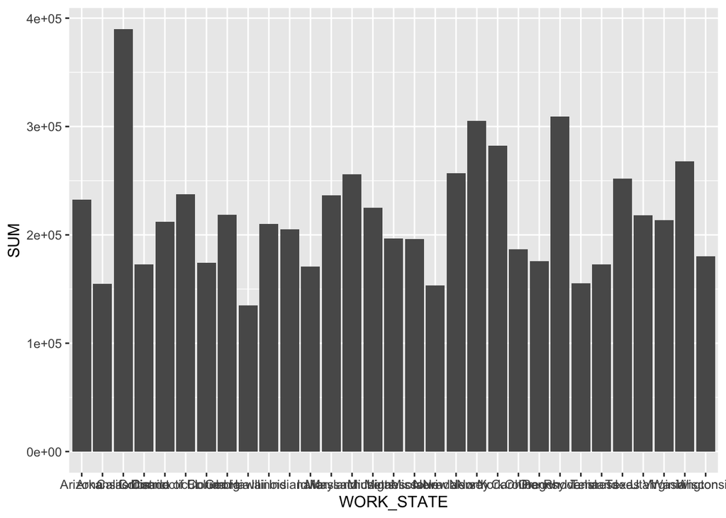

```r
total_dfm$SUM <- rowSums(total_dfm[ ,c(3,5)])

#trying to plot this
ggplot(data=total_dfm, aes(x=WORK_STATE, y=SUM)) +
  geom_bar(stat="identity")
```

Lets have another go at this

```r
#subsetting
data_interest = data.frame(salary_data_states[c("WORK_STATE", "JOB_TITLE_SUBGROUP", "PAID_WAGE_PER_YEAR")])
data_int = na.exclude(data_interest)

#data_int$JOB <- with(data_int, ifelse(JOB_TITLE_SUBGROUP == "data analyst", 1, 0))
newdata <- data_int[ which(data_int$JOB_TITLE_SUBGROUP== c('data analyst', 'data scientist')),]
#group by each state
ndf = distinct(newdata, WORK_STATE, .keep_all = TRUE)

#sub-setting high paid states
ndff <- ndf[ndf$WORK_STATE %in% c("California", "New York", "Washington", "New Jersey", "Texas", "Massachusetts") ,]

#ggplot(data=ndff, aes(x=ndf$WORK_STATE, y=ndf$PREVAILING_WAGE_PER_YEAR, fill=ndf$JOB_TITLE_SUBGROUP)) + geom_bar(stat="identity")
```

Let’s try again for something clearer

```r
# I need to make a new dataset with column that has data analyst and data scientist in same column and prevailing wage in same column

group <- newdata%>%group_by(WORK_STATE, JOB_TITLE_SUBGROUP)%>%summarise_all(funs(mean))
# Removing states I would not want to live in (too hot):
grouped<-  subset(group, WORK_STATE!="Florida" & WORK_STATE!="Louisiana")


#select states with highest pay in data related jobs
sorted_total <- total_dfm[order(-total_dfm$SUM),]
```

Lets put these together in a graph to commit to my branch:

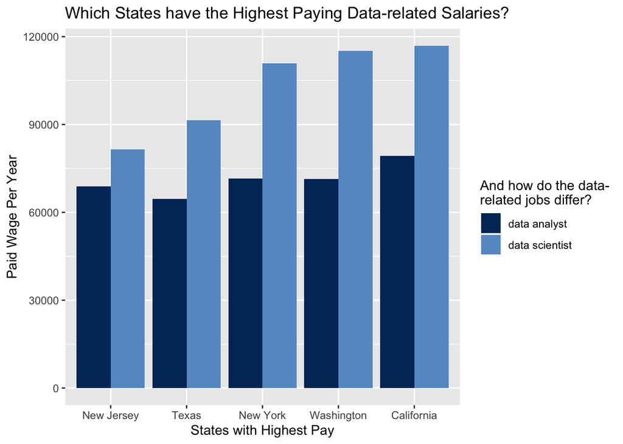

```r
groupedstates <- grouped[grouped$WORK_STATE %in% c("California", "New York", "Washington", "New Jersey", "Texas") ,]


 ggplot(data = groupedstates, aes(x = forcats::fct_reorder(WORK_STATE, PAID_WAGE_PER_YEAR, .fun = mean), y = PAID_WAGE_PER_YEAR, fill=groupedstates$JOB_TITLE_SUBGROUP)) +
  geom_bar(stat="identity", position=position_dodge()) +
  labs(x="States with Highest Pay", y="Paid Wage Per Year") +
  ggtitle("Which States have the Highest Paying Data-related Salaries?")+
  guides(fill=guide_legend(title="And how do the data-\nrelated jobs differ?"))+
  scale_fill_manual(values=c('#003366', '#6699CC'))
```

This graph will cover the first two parts of the question. (What states (of those I am willing to move to) have the highest paying data-related salaries? Differences between job sub-categories?)

Next question: Which companies have the highest salaries for those sub-types?

```r
companies = data.frame(salary_data_states[c("EMPLOYER_NAME", "WORK_STATE", "JOB_TITLE_SUBGROUP", "PAID_WAGE_PER_YEAR")])
comp = na.exclude(companies)
#subset data jobs and sort by prevailing wage
comp_sal <- comp[ which(comp$JOB_TITLE_SUBGROUP== c('data analyst', 'data scientist')),]

comp_sal_sort <- comp_sal[order(-comp_sal$PAID_WAGE_PER_YEAR),]
#distinct company and group salary by wage for scientist and analyst
com_da = comp_sal_sort[comp_sal_sort$JOB_TITLE_SUBGROUP== c('data analyst'),]
com_ds = comp_sal_sort[comp_sal_sort$JOB_TITLE_SUBGROUP== c('data scientist'),]

comp_states1 <- com_da[com_da$WORK_STATE %in% c("California", "New York", "Washington", "New Jersey", "Texas", "Massachusetts") ,]

comp_states2 <- com_ds[com_ds$WORK_STATE %in% c("California", "New York", "Washington", "New Jersey", "Texas", "Massachusetts") ,]


highest_da <- comp_states1 %>%                  # Company with the highest salary for data analysis in each state
  arrange(desc(PAID_WAGE_PER_YEAR)) %>%
  group_by(WORK_STATE) %>%
  slice(1)


highest_ds <- comp_states2 %>%                  # Company with the highest salary for data science in each state
  arrange(desc(PAID_WAGE_PER_YEAR)) %>%
  group_by(WORK_STATE) %>%
  slice(1)

highest_states_da <- highest_da[order(-highest_da$PAID_WAGE_PER_YEAR),]
highest_states_ds <- highest_ds[order(-highest_ds$PAID_WAGE_PER_YEAR),]
```

Putting these into graphs

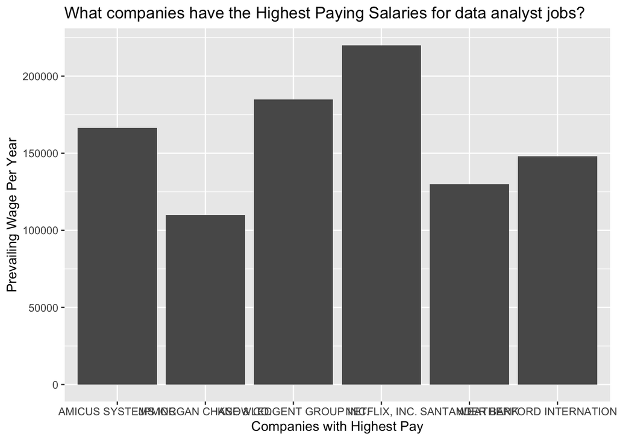

```r
ggplot(data=highest_states_da, aes(x= EMPLOYER_NAME, y= PAID_WAGE_PER_YEAR)) +
  geom_bar(stat="identity") +
  labs(x="Companies with Highest Pay", y="Prevailing Wage Per Year") +
  ggtitle("What companies have the Highest Paying Salaries for data analyst jobs?")
```

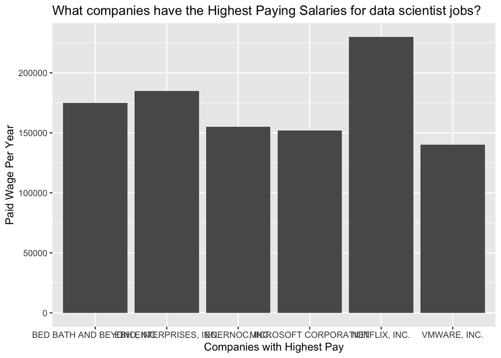

```r
ggplot(data=highest_states_ds, aes(x= EMPLOYER_NAME, y= PAID_WAGE_PER_YEAR)) +
  geom_bar(stat="identity") +
  labs(x="Companies with Highest Pay", y="Paid Wage Per Year") +
  ggtitle("What companies have the Highest Paying Salaries for data scientist jobs?")
```

```r
# head of each dataframe aka top 6 for each
kable(highest_states_da, caption = "Companies that pay the highest for Data Analyst positions in the 6 Highest Paying States")
```

Companies that pay the highest for Data Analyst positions in the 6 Highest Paying States

| EMPLOYER_NAME | WORK_STATE | JOB_TITLE_SUBGROUP | PAID_WAGE_PER_YEAR |
| --- | --- | --- | --- |
| NETFLIX, INC. | California | data analyst | 220000 |
| KNOWLEDGENT GROUP INC. | New Jersey | data analyst | 185000 |
| AMICUS SYSTEMS INC | New York | data analyst | 166400 |
| WEATHERFORD INTERNATIONAL, INC. | Texas | data analyst | 148000 |
| SANTANDER BANK | Massachusetts | data analyst | 130000 |
| JPMORGAN CHASE & CO. | Washington | data analyst | 110000 |

```r
kable(highest_states_ds, caption = "Companies that pay the highest for Data Scientist positions in the 6 Highest Paying States")
```

Companies that pay the highest for Data Scientist positions in the 6 Highest Paying States

| EMPLOYER_NAME | WORK_STATE | JOB_TITLE_SUBGROUP | PAID_WAGE_PER_YEAR |
| --- | --- | --- | --- |
| NETFLIX, INC. | California | data scientist | 230000 |
| EBH ENTERPRISES, INC. | New York | data scientist | 185000 |
| BED BATH AND BEYOND, INC. | New Jersey | data scientist | 175000 |
| ENERNOC, INC. | Massachusetts | data scientist | 155000 |
| MICROSOFT CORPORATION | Washington | data scientist | 152000 |
| VMWARE, INC. | Texas | data scientist | 140000 |

```r
 write.csv(highest_states_da,file="/Users/LilyRoseSlater/Documents/Rwork/311/highest_states_da.csv")

 write.csv(highest_states_ds,file="/Users/LilyRoseSlater/Documents/Rwork/311/highest_states_ds.csv")
```